# 2015 Whitehouse Administration Data Exploration

## A DataQuest Guided Project

I aim to leverage the Whitehouse Salary dataset to recap some of the lessons learned throughout the DataQuest Python Intermediate and Data Analysis With Pandas courses. Since I am new to Jupyter Notebooks, this exercise will also allow me to explore the features of this web application.

### Introduction

I'll begin by loading the dataset and outputting the resulting DataFrame.

```python
import pandas as pd

whitehouse = pd.read_csv("2015_white_house.csv")

whitehouse
```

|  | Name | Status | Salary | Pay Basis | Position Title |
| --- | --- | --- | --- | --- | --- |
| 0 | Abdullah, Hasan A. | Detailee | 105960 | Per Annum | POLICY ADVISOR |
| 1 | Abraham, Sabey M. | Employee | 55000 | Per Annum | ENERGY AND ENVIRONMENT DIRECTOR FOR PRESIDENTI... |
| 2 | Abraham, Yohannes A. | Employee | 121200 | Per Annum | SPECIAL ASSISTANT TO THE PRESIDENT AND CHIEF O... |
| 3 | Abramson, Jerry E. | Employee | 155035 | Per Annum | DEPUTY ASSISTANT TO THE PRESIDENT AND DIRECTOR... |
| 4 | Adler, Caroline E. | Employee | 114000 | Per Annum | SPECIAL ASSISTANT TO THE PRESIDENT AND DIRECTO... |
| 5 | Aiyer, Vikrum D. | Detailee | 134662 | Per Annum | SENIOR POLICY ADVISOR |
| 6 | Alcantara, Elias | Employee | 65650 | Per Annum | ASSOCIATE DIRECTOR OF INTERGOVERNMENTAL AFFAIRS |
| 7 | Ali, Mohammed I. | Employee | 42000 | Per Annum | STAFF ASSISTANT |
| 8 | Allen, Angelica P. | Employee | 50000 | Per Annum | SPECIAL ASSISTANT TO THE DIRECTOR OF THE OFFIC... |
| 9 | Allen, Elizabeth M. | Employee | 103000 | Per Annum | SPECIAL ASSISTANT TO THE PRESIDENT FOR MESSAGE... |
| 10 | Allen, Jessica L. | Employee | 42844 | Per Annum | PRESS ASSISTANT |
| 11 | Allison, Ashley R. | Employee | 97000 | Per Annum | DEPUTY DIRECTOR OF PUBLIC ENGAGEMENT |
| 12 | Amendolare, Vincent C. | Employee | 42420 | Per Annum | ANALYST |
| 13 | Amuluru, Uma M. | Detailee | 116804 | Per Annum | ASSOCIATE COUNSEL |
| 14 | Anderson, Amanda D. | Employee | 126250 | Per Annum | SPECIAL ASSISTANT TO THE PRESIDENT AND HOUSE L... |
| 15 | Anderson, Charles D. | Employee | 101000 | Per Annum | SENIOR ADVISOR FOR THE NATIONAL ECONOMIC COUNCIL |
| 16 | Aniskoff, Paulette L. | Employee | 155035 | Per Annum | DEPUTY ASSISTANT TO THE PRESIDENT AND DIRECTOR... |
| 17 | Ashton, Nathaniel R. | Employee | 42000 | Per Annum | STAFF ASSISTANT |
| 18 | Austin, Jr., Roy L. | Employee | 160085 | Per Annum | DEPUTY ASSISTANT TO THE PRESIDENT FOR THE OFFI... |
| 19 | Axios, Ashleigh T. | Employee | 73225 | Per Annum | DIGITAL CREATIVE DIRECTOR |
| 20 | Babajide, Ayotunde T. | Detailee | 114480 | Per Annum | SENIOR POLICY ADVISOR |
| 21 | Bae, Yena | Employee | 44000 | Per Annum | SENIOR ANALYST AND PROJECT MANAGER |
| 22 | Baker, Sarah E. | Employee | 131805 | Per Annum | SPECIAL ASSISTANT TO THE PRESIDENT AND ASSOCIA... |
| 23 | Bansal, Gaurab | Employee | 120000 | Per Annum | DEPUTY ASSISTANT TO THE PRESIDENT AND DEPUTY C... |
| 24 | Barnes, Desiree N. | Employee | 42844 | Per Annum | PRESS ASSISTANT |
| 25 | Bartoloni, Kristen A. | Employee | 70000 | Per Annum | DEPUTY DIRECTOR OF RESEARCH |
| 26 | Beckford, Kevin F. | Employee | 42000 | Per Annum | ANALYST |
| 27 | Beliveau, Emmett S. | Employee | 160085 | Per Annum | ASSISTANT TO THE PRESIDENT AND DIRECTOR OF THE... |
| 28 | Benenati, Frank J. | Employee | 84840 | Per Annum | ASSISTANT PRESS SECRETARY |
| 29 | Bennett, Tabitha R. | Employee | 50000 | Per Annum | PRESS LEAD |
| ... | ... | ... | ... | ... | ... |
| 444 | Vignarajah, Krishanti | Employee | 90000 | Per Annum | DIRECTOR OF INTERNATIONAL AFFAIRS AND SENIOR P... |
| 445 | Vilfer, Ryan E. | Employee | 42420 | Per Annum | STAFF ASSISTANT |
| 446 | Vorhaus, David A. | Employee | 111100 | Per Annum | SPECIAL ASSISTANT TO THE PRESIDENT AND ADVISOR... |
| 447 | Vrazilek, Lauren S. | Employee | 55000 | Per Annum | DEPUTY PRESS SECRETARY FOR THE FIRST LADY |
| 448 | Wagstaff, Jesica E. | Employee | 45905 | Per Annum | LEGISLATIVE ASSISTANT AND ASSISTANT TO THE SEN... |
| 449 | Waheed, Manar | Employee | 80800 | Per Annum | DEPUTY POLICY DIRECTOR FOR IMMIGRATION |
| 450 | Wainscott, Kip F. | Detailee | 134662 | Per Annum | SENIOR DIRECTOR OF CABINET AFFAIRS |
| 451 | Waldo, Katherine A. | Employee | 47470 | Per Annum | TRIP COORDINATOR |
| 452 | Wall, Alexander B. | Employee | 63125 | Per Annum | DEPUTY DIRECTOR OF ONLINE ENGAGEMENT |
| 453 | Walsh, James D. | Detailee | 171871 | Per Annum | ASSOCIATE COUNSEL |
| 454 | Walsh, Joan L. | Employee | 160085 | Per Annum | DEPUTY ASSISTANT TO THE PRESIDENT AND STAFF SE... |
| 455 | Wang, Ya W. | Employee | 85000 | Per Annum | SPECIAL ASSISTANT AND ADVISOR TO THE CHIEF OF ... |
| 456 | Whisenant, Addie M. | Employee | 78780 | Per Annum | DIRECTOR OF AFRICAN-AMERICAN MEDIA |
| 457 | Wild, Clayton S. | Employee | 44000 | Per Annum | PRESIDENTIAL WRITER |
| 458 | Wilkinson, Jr., David E. | Employee | 100000 | Per Annum | DIRECTOR, OFFICE OF SOCIAL INNOVATION AND CIVI... |
| 459 | Williams, Sherman A. | Employee | 80716 | Per Annum | ASSISTANT TO THE EXECUTIVE CLERK |
| 460 | Winter, Melissa E. | Employee | 133320 | Per Annum | DEPUTY ASSISTANT TO THE PRESIDENT AND SENIOR A... |
| 461 | Wong, Jacqueline | Employee | 58075 | Per Annum | SENIOR POLICY ANALYST |
| 462 | Wright, Frank B. | Employee | 65000 | Per Annum | DEPUTY DIRECTOR FOR FINANCE |
| 463 | Wu, Alexander P. | Employee | 52520 | Per Annum | ASSOCIATE DIRECTOR FOR THE MANAGEMENT AND ADMI... |
| 464 | Xharda, Klevis | Employee | 42420 | Per Annum | EXECUTIVE ASSISTANT |
| 465 | Yaros, Stephen G. | Employee | 42000 | Per Annum | STAFF ASSISTANT |
| 466 | Young, Caitlin E. | Employee | 63630 | Per Annum | STENOGRAPHER |
| 467 | Young, Jr., Reginald D. | Employee | 69597 | Per Annum | SENIOR MANAGEMENT ANALYST |
| 468 | Young, Kimberly E. | Employee | 45000 | Per Annum | LEGISLATIVE ASSISTANT |
| 469 | Young, Stephanie L. | Employee | 87870 | Per Annum | ASSOCIATE COMMUNICATIONS DIRECTOR |
| 470 | Young, Valerie A. | Employee | 52667 | Per Annum | RECORDS MANAGEMENT ANALYST |
| 471 | Yudelson, Alex R. | Employee | 42000 | Per Annum | STAFF ASSISTANT |
| 472 | Zaid, Zaid A. | Detailee | 158700 | Per Annum | ASSOCIATE COUNSEL |
| 473 | Zients, Jeffrey D. | Employee | 173922 | Per Annum | ASSISTANT TO THE PRESIDENT FOR ECONOMIC POLICY... |

474 rows × 5 columns

### Salary Data

Next, let's draw some basic insights into the Salary Data.

What is the distribution of salaries?

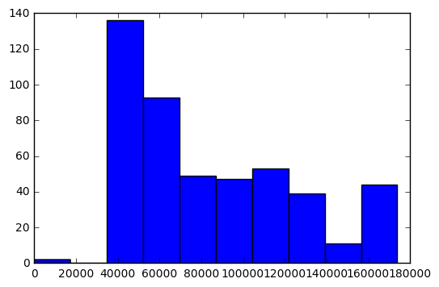

```python
%matplotlib inline
import matplotlib.pyplot as plt

plt.hist(whitehouse["Salary"])
plt.show()
```

Who is making the least amount of money?

```python
minsalary = whitehouse["Salary"].min()
minrows = whitehouse[whitehouse["Salary"] == minsalary]
minrows
```

|  | Name | Status | Salary | Pay Basis | Position Title |
| --- | --- | --- | --- | --- | --- |
| 243 | Leary, Kimberlyn R. | Employee | 0 | Per Annum | ADVISOR TO THE COUNCIL ON WOMEN AND GIRLS |
| 326 | Park, Todd Y. | Employee | 0 | Per Annum | ADVISOR FOR TECHNOLOGY |

Who is making the most amount of money?

```python
maxsalary = whitehouse["Salary"].max()
maxrows = whitehouse[whitehouse["Salary"] == maxsalary]
maxrows
```

|  | Name | Status | Salary | Pay Basis | Position Title |
| --- | --- | --- | --- | --- | --- |
| 52 | Breckenridge, Anita J. | Employee | 173922 | Per Annum | ASSISTANT TO THE PRESIDENT AND DEPUTY CHIEF OF... |
| 70 | Canegallo, Kristie A. | Employee | 173922 | Per Annum | ASSISTANT TO THE PRESIDENT AND DEPUTY CHIEF OF... |
| 90 | Cushman, Chase M. | Employee | 173922 | Per Annum | ASSISTANT TO THE PRESIDENT AND DIRECTOR OF SCH... |
| 117 | Earnest, Joshua R. | Employee | 173922 | Per Annum | ASSISTANT TO THE PRESIDENT AND PRESS SECRETARY |
| 121 | Eggleston, Warren N. | Employee | 173922 | Per Annum | ASSISTANT TO THE PRESIDENT AND COUNSEL TO THE ... |
| 130 | Fallon, Katherine B. | Employee | 173922 | Per Annum | ASSISTANT TO THE PRESIDENT AND DIRECTOR OF THE... |
| 200 | Jarrett, Valerie B. | Employee | 173922 | Per Annum | SENIOR ADVISOR AND ASSISTANT TO THE PRESIDENT ... |
| 201 | Johnson, Broderick D. | Employee | 173922 | Per Annum | ASSISTANT TO THE PRESIDENT AND CABINET SECRETARY |
| 210 | Kale, Katy A. | Employee | 173922 | Per Annum | ASSISTANT TO THE PRESIDENT FOR MANAGEMENT AND ... |
| 216 | Keenan, Cody S. | Employee | 173922 | Per Annum | ASSISTANT TO THE PRESIDENT AND DIRECTOR OF SPE... |
| 280 | McDonough, Denis R. | Employee | 173922 | Per Annum | ASSISTANT TO THE PRESIDENT AND CHIEF OF STAFF |
| 297 | Monaco, Lisa O. | Employee | 173922 | Per Annum | ASSISTANT TO THE PRESIDENT FOR HOMELAND SECURI... |
| 304 | Muñoz, Cecilia | Employee | 173922 | Per Annum | ASSISTANT TO THE PRESIDENT AND DIRECTOR OF THE... |
| 358 | Rhodes, Benjamin J. | Employee | 173922 | Per Annum | ASSISTANT TO THE PRESIDENT AND DEPUTY NATIONAL... |
| 359 | Rice, Susan E. | Employee | 173922 | Per Annum | ASSISTANT TO THE PRESIDENT AND NATIONAL SECURI... |
| 403 | Simas, David M. | Employee | 173922 | Per Annum | ASSISTANT TO THE PRESIDENT AND DIRECTOR OF THE... |
| 426 | Tchen, Christina M. | Employee | 173922 | Per Annum | ASSISTANT TO THE PRESIDENT AND CHIEF OF STAFF ... |
| 473 | Zients, Jeffrey D. | Employee | 173922 | Per Annum | ASSISTANT TO THE PRESIDENT FOR ECONOMIC POLICY... |

How much does the White House pay in total salary per annum?

```python
import numpy as np

salaryperannum = whitehouse.pivot_table(index="Pay Basis", values="Salary", aggfunc=np.sum)

salaryperannum
```

```
Pay Basis
Per Annum    40225595
Name: Salary, dtype: int64
```

Based on what we can see above, there may be a correlation between the length of the Position Titles and salary.

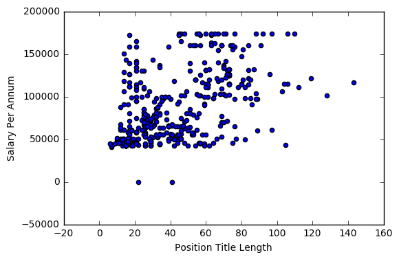

```python
positionlength = whitehouse["Position Title"].apply(len)
whitehouse["Position Length"] = positionlength

plt.scatter(whitehouse["Position Length"], whitehouse["Salary"])
plt.xlabel('Position Title Length')
plt.ylabel("Salary Per Annum")
```

The scatter shows a high concentration of Salaries < 100K having Position Titles with less than ~60 characters. Salaries above 100K appear to have Position Titles with more than ~60 characters in general.

### Other Data

Below are the top 10 most common words used in the Position Titles.

```python
import collections as cl

seq = " "
cl.Counter(seq.join(whitehouse["Position Title"]).split()).most_common(10)
```

```
[('THE', 218),
 ('ASSISTANT', 215),
 ('TO', 172),
 ('AND', 168),
 ('OF', 155),
 ('DIRECTOR', 146),
 ('PRESIDENT', 135),
 ('SPECIAL', 102),
 ('FOR', 97),
 ('DEPUTY', 86)]
```

### Conclusion

Jupyter Notebook has been an easy way to explore this Whitehouse data set. In particular, I liked the ability to run code in blocks, and also the formatting provided by typing out variable names. While I have found myself cross-referencing this analysis in Excel, I hope that with continued practice I'll develop more expertise in both Python and using the Jupyter Notebook interface.